# Evolution of Message Diffusal Speed

## US Presidential Election Debate 3

#### July 10, 2018

For this analysis, I have extracted all “retweet chains” that had a length of more than 200. That is, the original tweet was retweeted *at least 200 times* within the timespan of the debate.

The retweet chain were ordered chronologically, and then the “**speed**” of retweets was calculated by using a N-retweet moving window, where speed is inverse (1/x) of time. For example:

let’s say a tweet got tweeteed at t=0, and retweeted at t=1,2,4,8

if we select the window length (N) to be 3, then

the the intial speed is 1/(2-0) = 0.5

For some other N, these values would be different. For this analysis, I have chosen N=114 for reasons I would skip here.

Below are some plots for the full dataset of debate 3. The color reflects how my followers the original tweeter has (note the log scale on color).

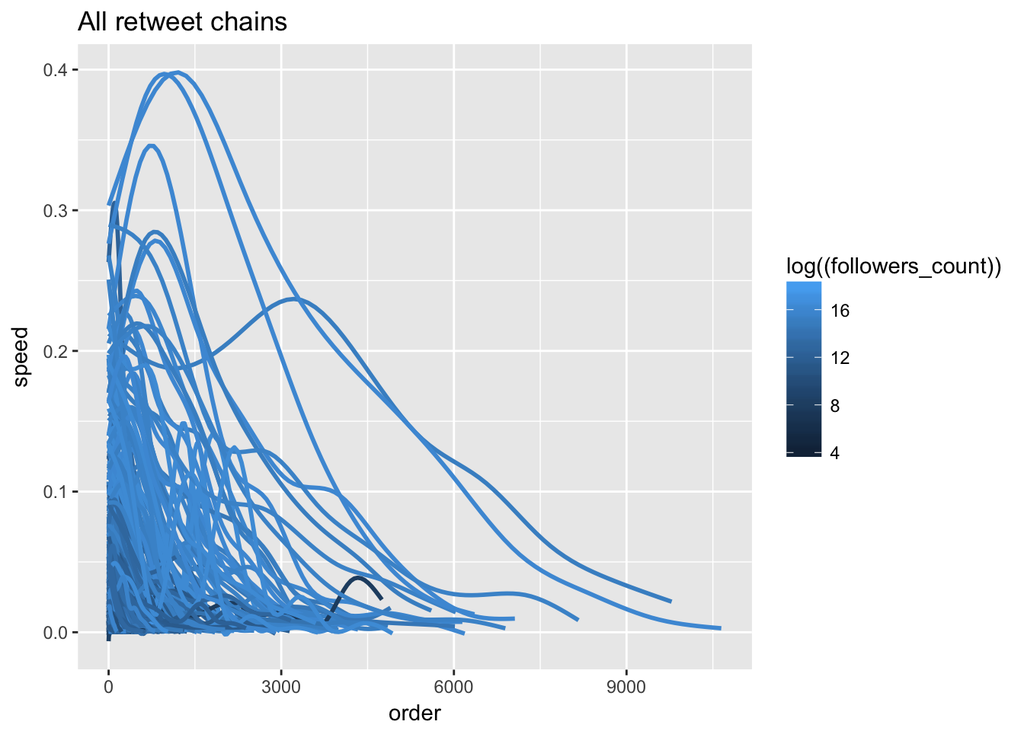

```r
library(tidyverse)
df <- read_csv("speed3_.csv")
ggplot(data=df,mapping=aes(x=order,y=speed, group=cat))+
  geom_smooth(se=FALSE,mapping = aes(color=log((followers_count))))+
  labs(title="All retweet chains")
```

Note that the retweet chains that do not extend to higher orders (right side of the x-axis) reflect that they are relatively shorter. In other words, they did not get retweeted as much.

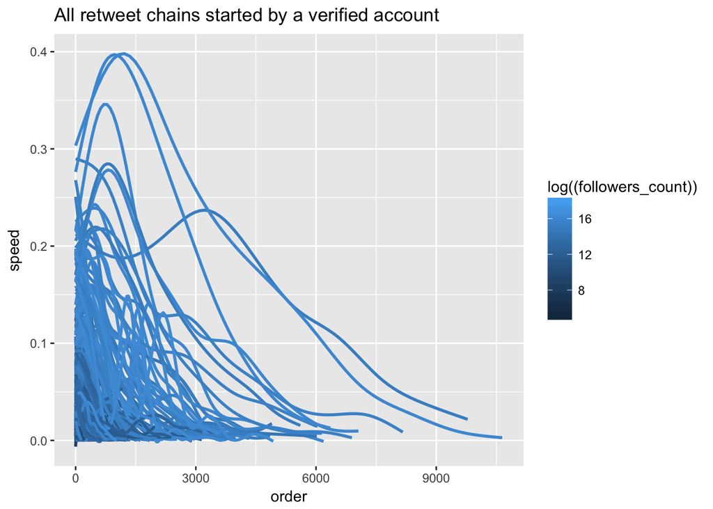

```r
ggplot(data=filter(df,verified=="True"),mapping=aes(x=order,y=speed, group=cat))+
  geom_smooth(se=FALSE,mapping = aes(color=log((followers_count))))+
  labs(title="All retweet chains started by a verified account")
```

> The general trend for the top two curves is how the speed increases rapidly, and then falls rapidly. This seems to suggest a mechanism of diffusal where the original tweeters themselves are powering the diffusion. The cases where there is a fall followed by a rise(s) might point to the tweet being retweeted by a user who is a central network node, which leads to an increase in the retweeting speed.

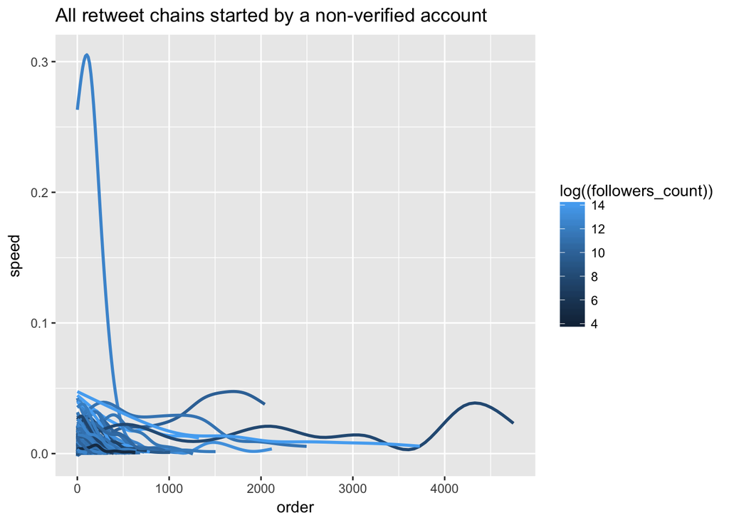

```r
ggplot(data=filter(df,verified=="False"),mapping=aes(x=order,y=speed, group=cat))+
  geom_smooth(se=FALSE,mapping = aes(color=log((followers_count))))+
  labs(title="All retweet chains started by a non-verified account")
```

Below, I am removing the anamolous case (really steep peak) in the above figure to get a better look.

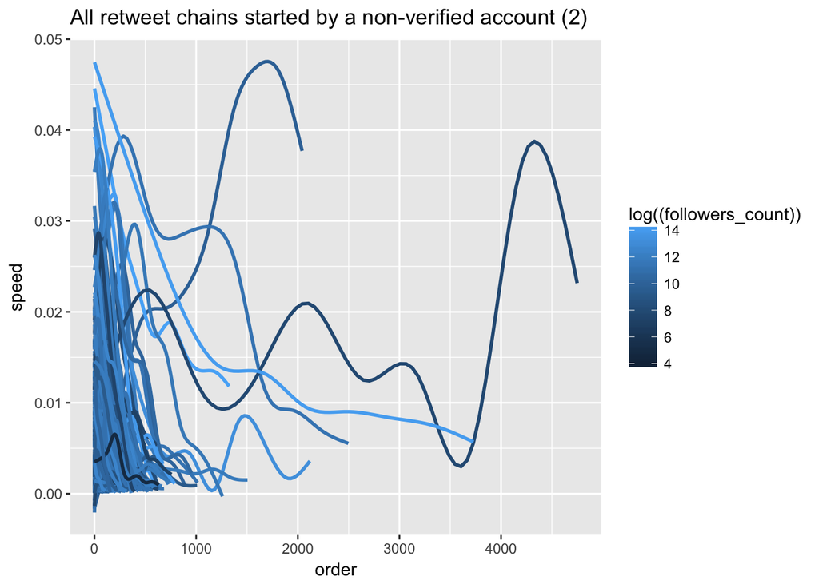

```r
ggplot(data=filter(df,verified=="False" & cat != 253),mapping=aes(x=order,y=speed, group=cat))+
  geom_smooth(se=FALSE,mapping = aes(color=log((followers_count))))+
  labs(title="All retweet chains started by a non-verified account (2)")
```

More interesting curves. The curve which extends to order > 4000 is by a twitter user *Oliverdirtyb* who had 2397 followers at that time, and tweeted [this](https://twitter.com/Oliverdirtyb/status/788918284984913920). *Oliverdirtyb* is now verified - maybe because of this tweet?!

One can isolate curves of interest. For example, *Oliverdirtyb*’s tweet:

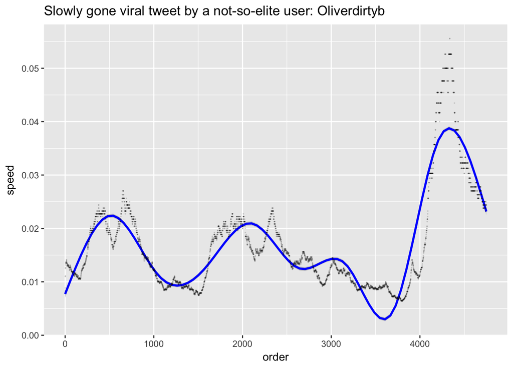

```r
ggplot(data=filter(df, cat == 1063),mapping=aes(x=order,y=speed, group=cat))+
  geom_smooth(se=TRUE,color="blue")+
  geom_point(alpha=0.1,size=0.1)+
  labs(title="Slowly gone viral tweet by a not-so-elite user: Oliverdirtyb")
```

Comparing the above to some elite’s tweets (color palette is only for clarity):

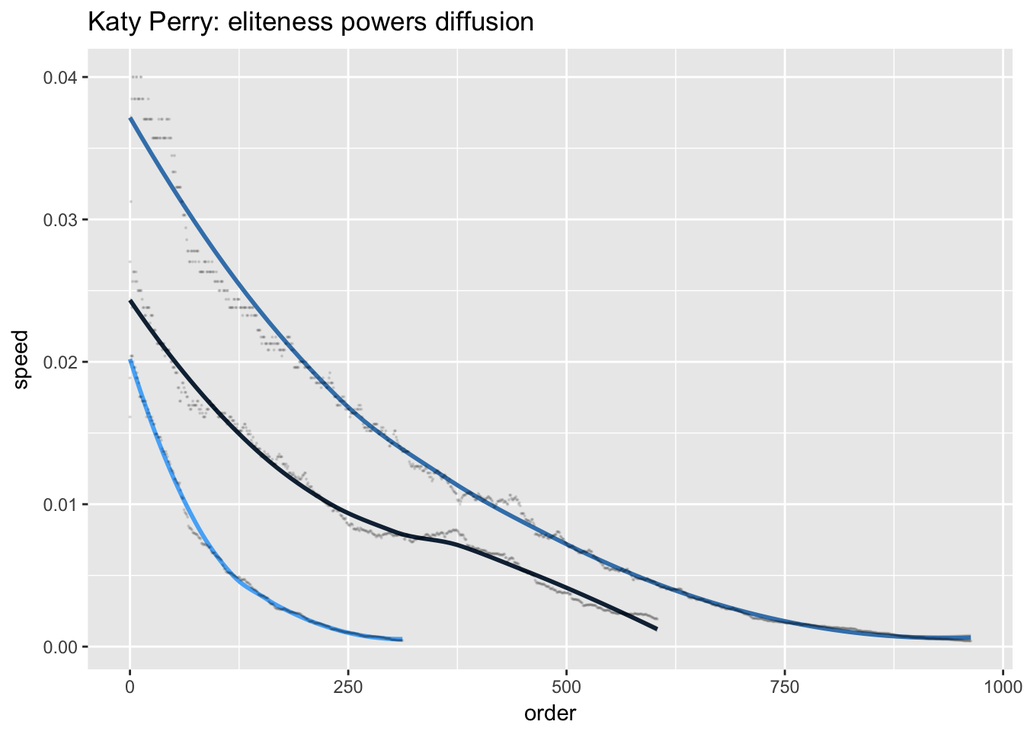

```r
ggplot(data=filter(df, user == "katyperry"),mapping=aes(x=order,y=speed, group=cat))+
  geom_smooth(se=TRUE,mapping=aes(color=cat))+
  geom_point(alpha=0.1,size=0.1)+
  labs(title="Katy Perry: eliteness powers diffusion")+
  theme(legend.position="none")
```

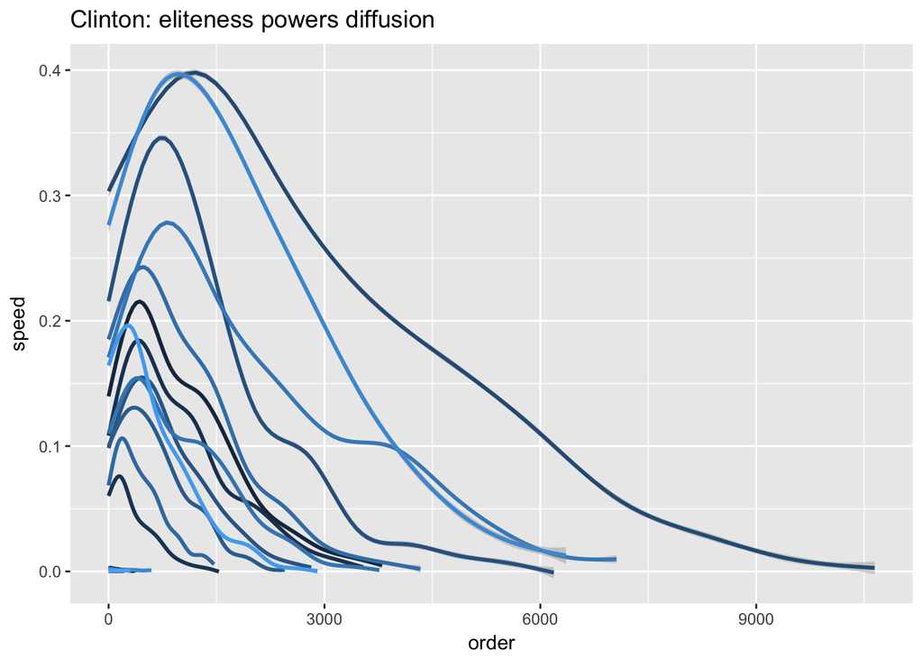

```r
ggplot(data=filter(df, user == "HillaryClinton"),mapping=aes(x=order,y=speed, group=cat))+
  geom_smooth(se=TRUE,mapping=aes(color=cat))+
  labs(title="Clinton: eliteness powers diffusion")+
  theme(legend.position="none")
```

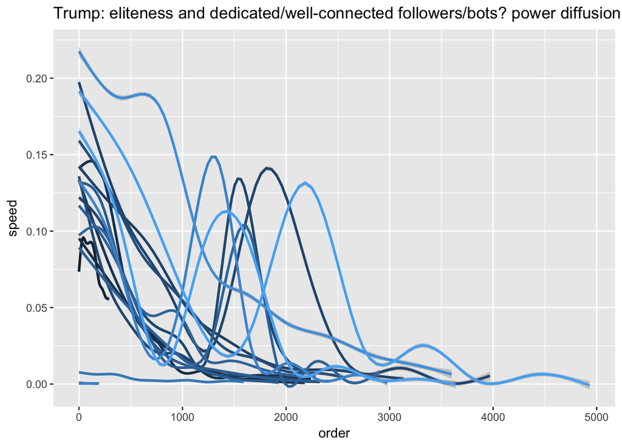

```r
ggplot(data=filter(df, user == "realDonaldTrump"),mapping=aes(x=order,y=speed, group=cat))+
  geom_smooth(se=TRUE,mapping=aes(color=cat))+
  labs(title="Trump: eliteness and dedicated/well-connected followers/bots? power diffusion")+
  theme(legend.position="none")
```

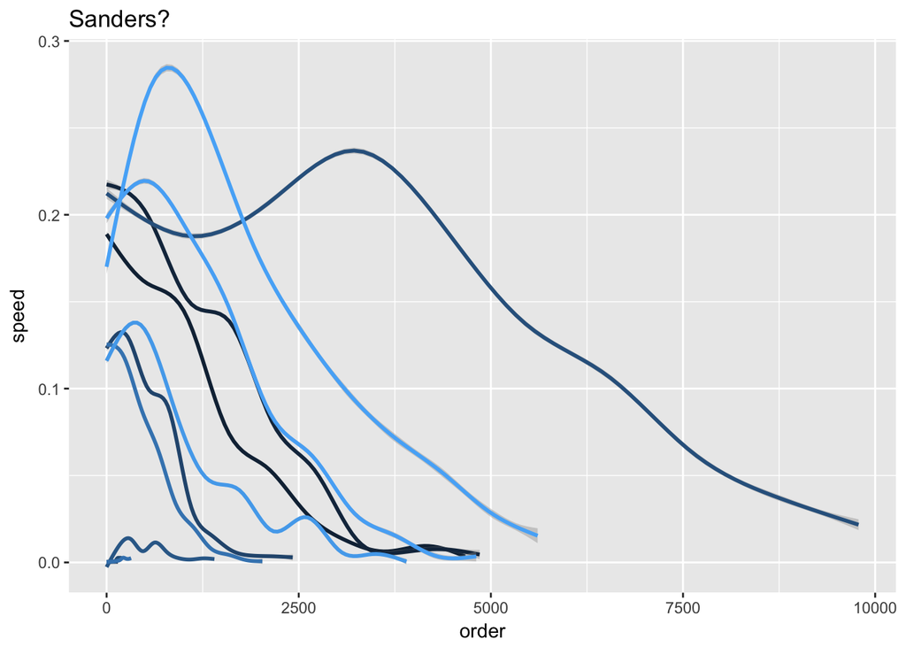

```r
ggplot(data=filter(df, user == "BernieSanders"),mapping=aes(x=order,y=speed, group=cat))+
  geom_smooth(se=TRUE,mapping=aes(color=cat))+
  labs(title="Sanders?")+
  theme(legend.position="none")
```